# Przykłady i rozwiązania

Michał Burdukiewicz

14-01-2024

Źródło danych: https://github.com/michbur/polish-driver-license

## Rysunek 1

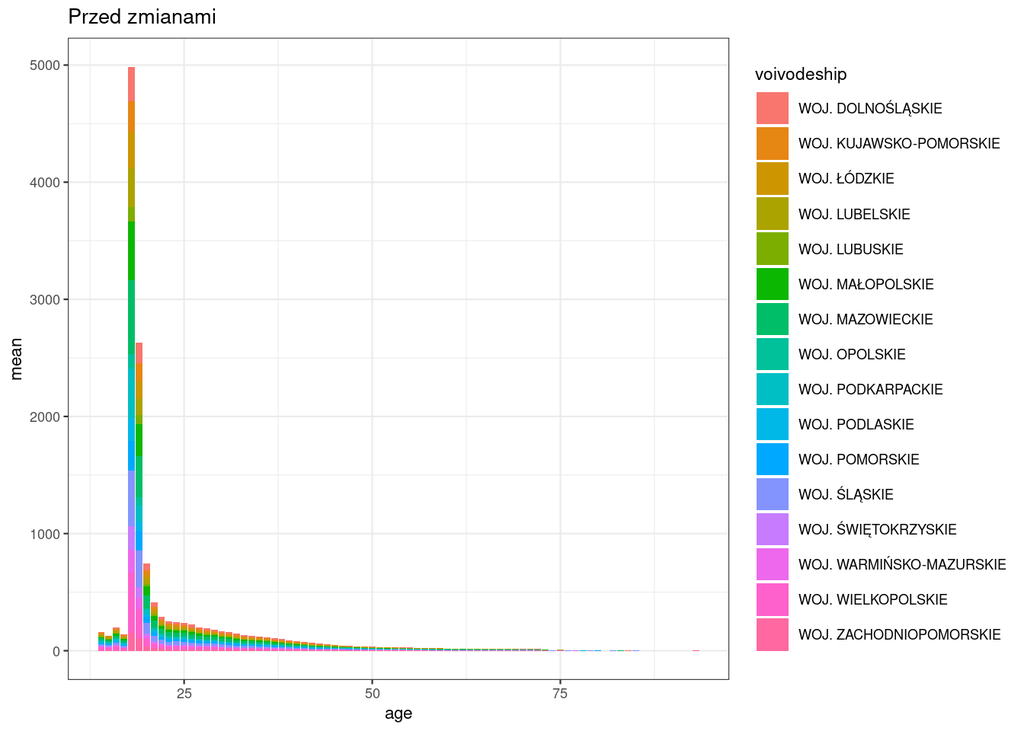

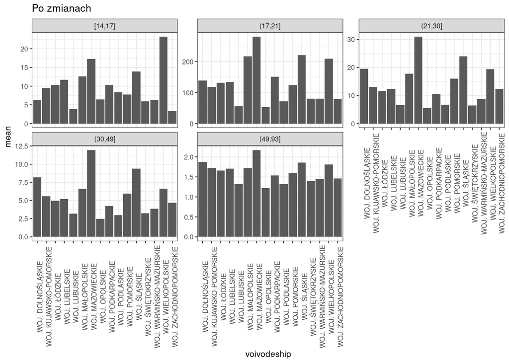

Cel: pokazanie średniej liczby osób, które uzyskały prawo jazdy w danym wieku w zależności od województwa.

**Geometria:** wykres słupkowy

**Facety:** każdy przedział wiekowy pokazać na oddzielnym wykresie, każdy wykres dla przedziału wiekowego ze wszystkimi województwami

**Statystyki:** oddzielne wykresy dla każdego przedziału wiekowego (przedziały: 14-17, 18-21, 22-30, 31-49, 50+)

## Rysunek 2

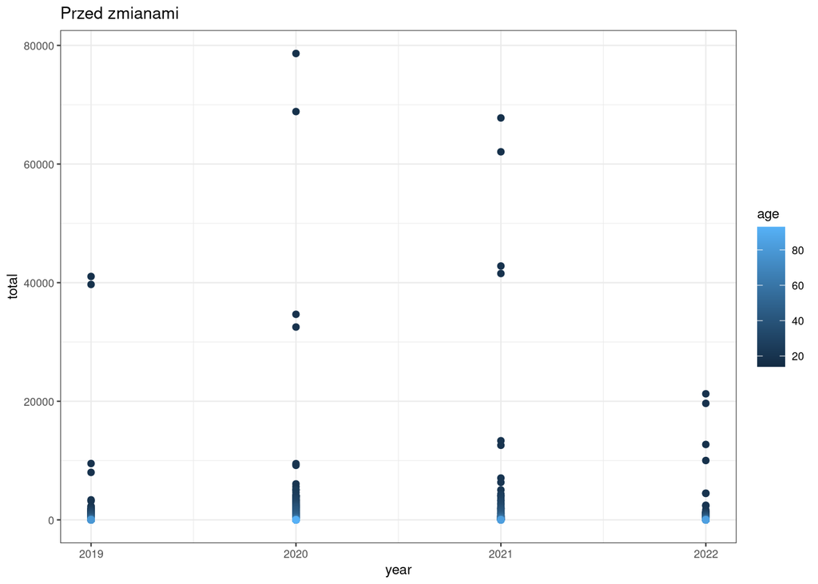

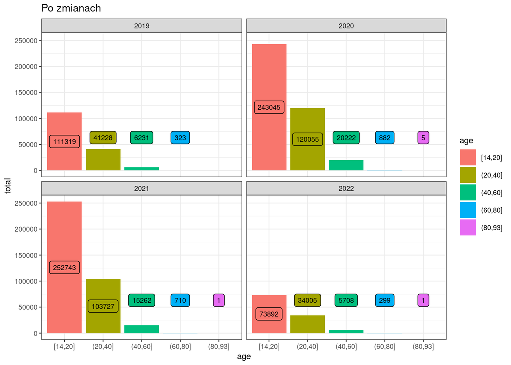

Cel: pokazanie liczby osób w danym wieku uzyskujących prawo jazdy w danym roku.

**Atrybuty wizualne:** - pojedyncza wizualizacja statyczna - oś “y” - całokowita liczba wydanych praw jazdy, oś “x” - wiek  
- kolor: osobne kolory dla słubków reprezentujących te same grupy wiekowe

**Facety:** cztery osobne obrazki, każdy przedstawiający pięc słupków (reprezentujących grupy wiekowe), jeden obrazek dla każego z poszczególnych roczników (2019-2022)

**Geometria:** słupkowy

**Statystyka:** zliczenie w grupach (min - 20, 20 - 40, 40 - 60, 60 - 80, pow. 80)

## Rysunek 3

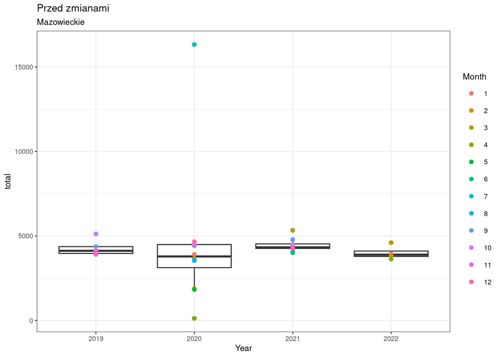

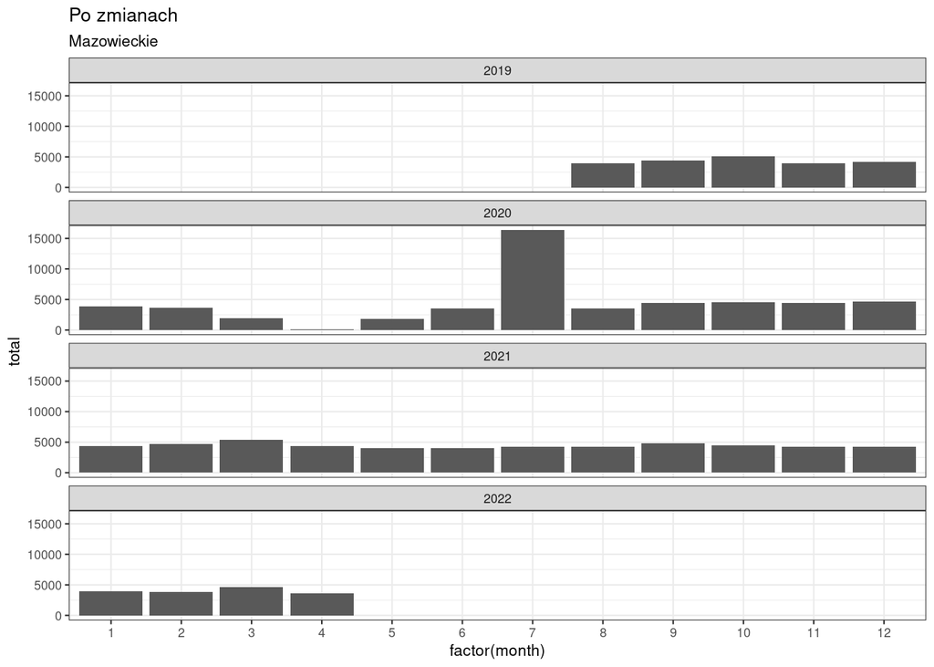

Cel: pokazanie zmienności liczby uzyskanych praw jazdy w skali roku w zależności od roku w województwie mazowieckim.

**Opis ogólny:** Rezygnujemy z wykresu pudełkowego i punktowego. Zmieniamy na wykres 4 facetowy (każdy facet pokazuje jeden rok), ułożony horyzontalnie, każdy miesiąc jest osobnym słupkiem (mamy więc 12 słupków)

**Atrybuty:** oś x - miesiące, oś y - suma, takie same skale na osi y, rezygnujemy z koloru

**Geometria:** wykres słupkowy

**Facety:** 4 facety, każdy pokazuje 1 rok

**Statystyki:** Rezygnujemy ze statystyk: mediany/kwartyli, pozostawiamy tylko zliczenia (sumę praw jazdy w każdym miesiącu w danym roku)

## Rysunek 4

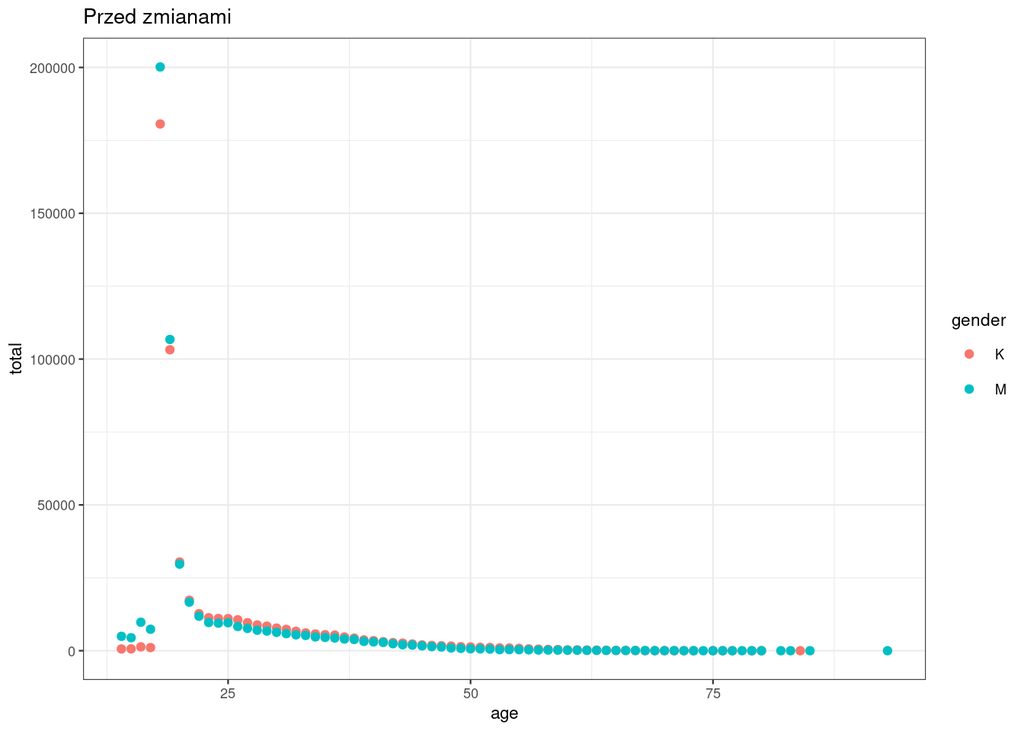

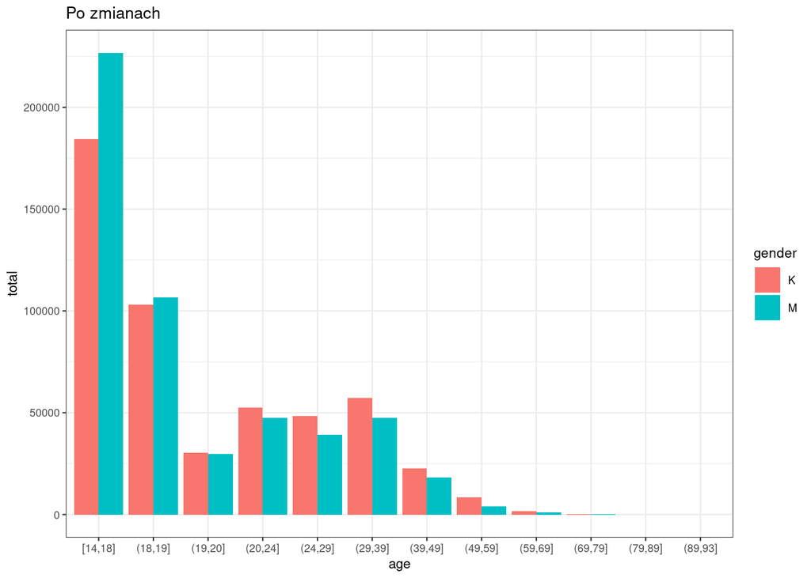

Cel: pokazać zależność liczby uzyskanych praw jazdy w zależności od wieku i płci.

**Opis ogólny:** zrezygnowanie z wykresu punktowego na rzecz wykresu słupkowego, rozróżnienie kolorystyczne na płeć pozostaje niezmienione, ponowne zliczenie uzyskanych praw jazdy dla przedziałów wiekowych. Zmiany te pozwolą poprawić czytelność wykresu.

**Atrybuty:** - oś X opisuje wiek/przedział wiekowy, oś Y - liczbę uzyskanych praw jazdy, kolor słupka jako oznaczenie płci

**Geometria:** - zmiana z wykresu punktowego na słupkowy, dwa słupki obok siebie (osobne dla płci oznaczone kolorami obecnych kropek), odstępy między słupkami dla różnych przedziałów wiekowych

**Facety:** - brak,

## Rysunek 5

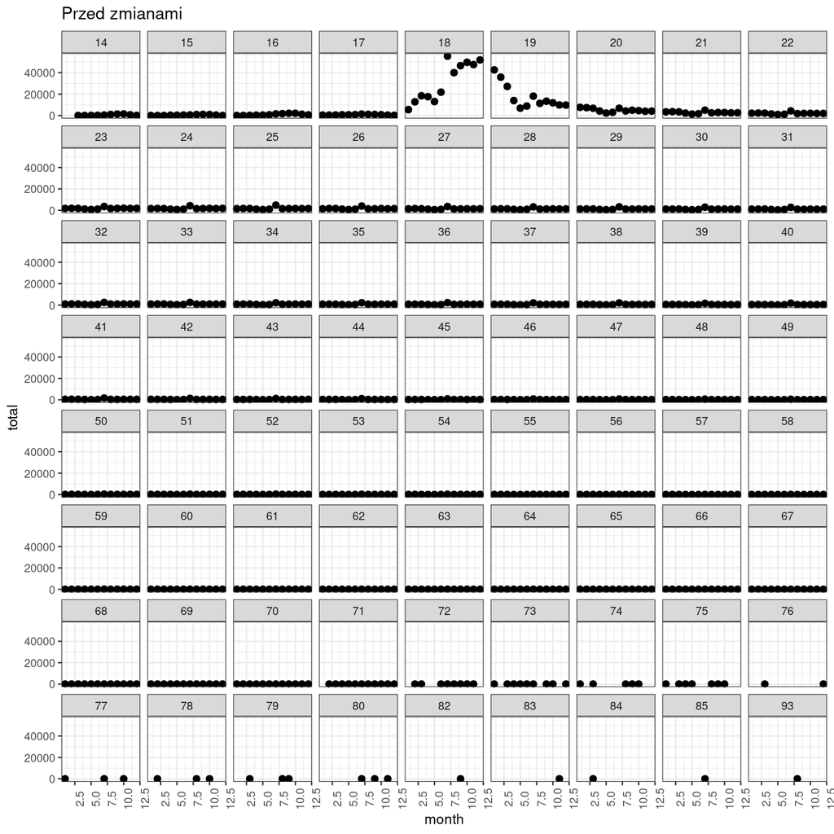

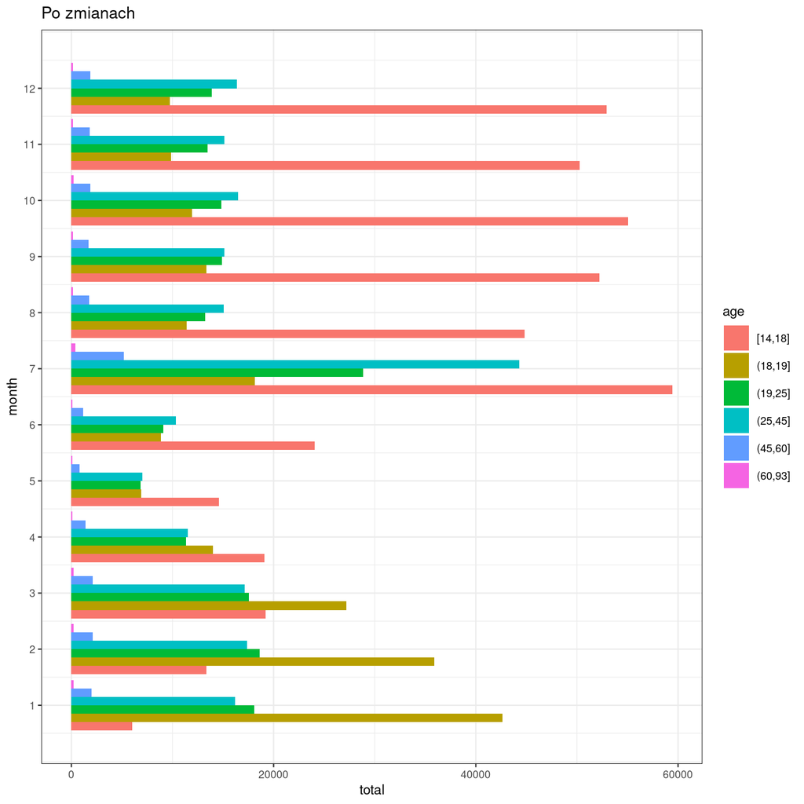

Cel: pokazać liczbę praw jazdy uzyskiwanych przez osoby w różnym wieku w zależności od miesiąca.

-> **Geometrie:** słupki poziome

-> **Fasety:** brak

-> **Statystyki:** skumulowana suma wydanych praw jazdy

## Rysunek 6

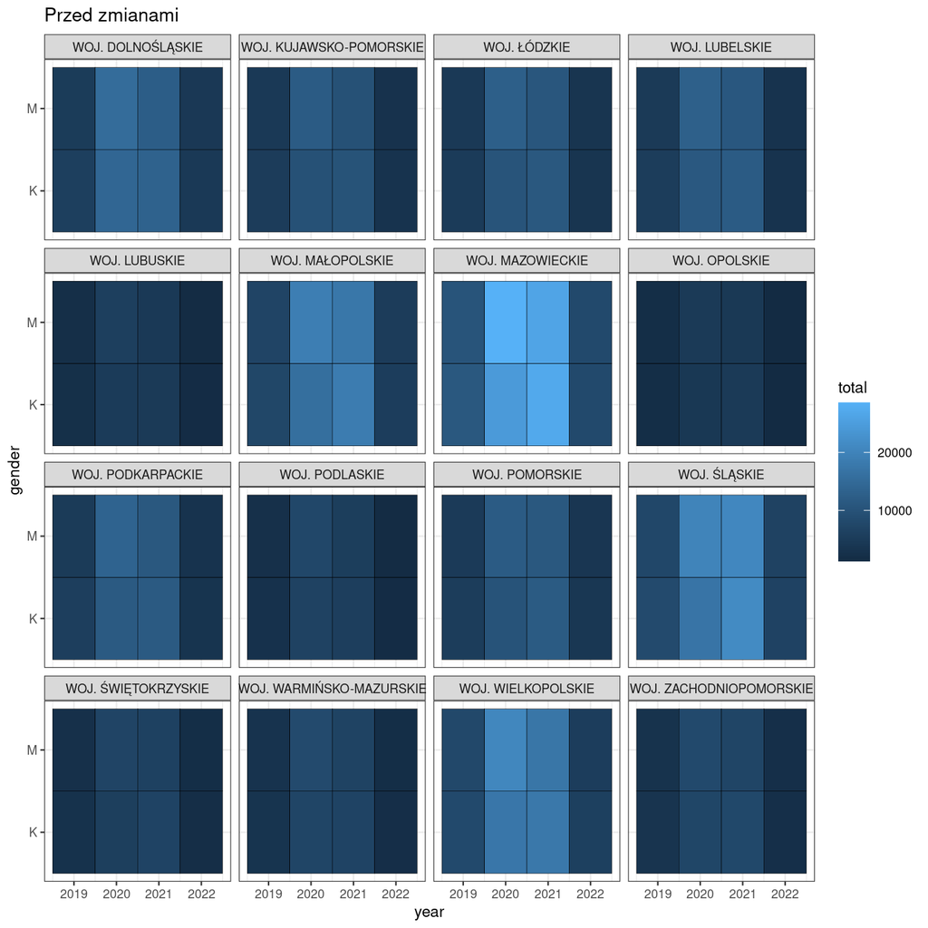

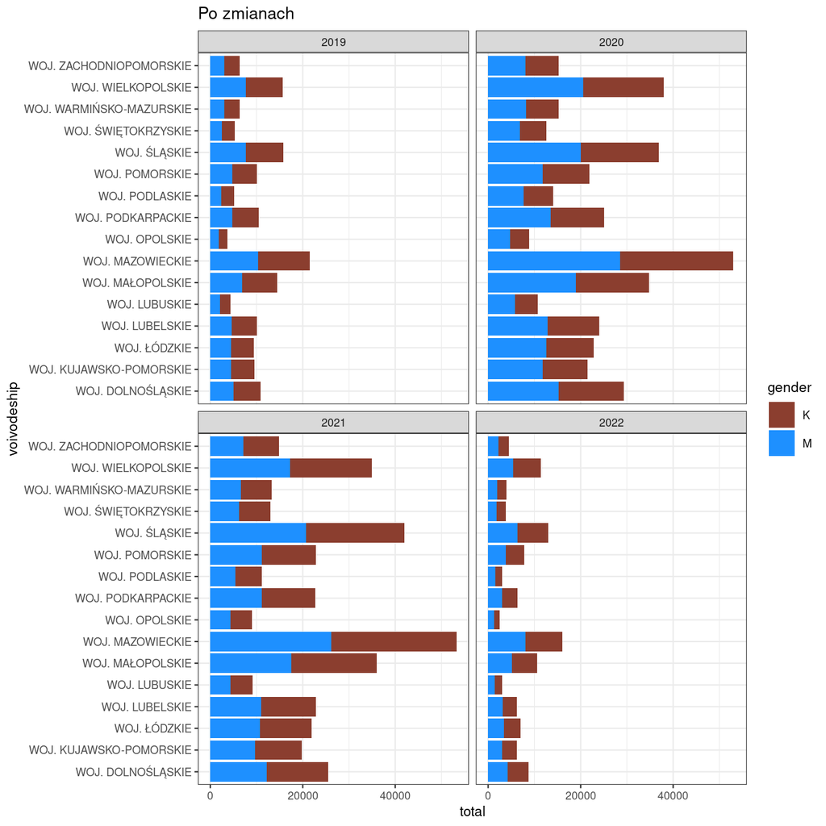

Cel: pokazać liczbę uzyskanych praw jazdy dla poszczególnych województw w zależności od płci i roku.

- **Atrybuty:** ->oś x ilosc wydanych prawo jazdy (jeśli różnice między długością słupków będą zbyt duże, to można zastosowac skalę logarytmiczną) -> oś y województwa -> usunięcie gradientu -> jeden kolor dla kobiet (brązowy) i jeden kolor dla mężczyzn (niebieski), stacked - uwzględnione w legendzie
- **Geometria:** ->zmiana na wykres słupkowy
- **Facety:** podział na lata
- **Statystyka:** zliczenie